# R Notebook on Fish Survival

### Load required packages

```r
library(ggplot2)
library(tidyr)
library(magrittr)
library(dplyr)
library(survival)
library(survminer)
library(purrr)
library(boot)
library(muhaz)
```

### Load data

Read the CSV file. The date columns need to be parsed, and missing deaths replaced with 0.

```r
data = read.csv('deathdata.csv')
data$dob = as.Date(data$dob, '%d/%m/%Y')
data$death_date = as.Date(data$death_date, '%d/%m/%Y')
data$status_date = as.Date(data$status_date, '%d/%m/%Y')
data$death_number[is.na(data$death_number)] = 0
# drop all stock where 0 fish came out of the nursery
data = filter(data, nursery_out > 0)
# don't count deaths in the nursery
data$death_number[data$death_description == 'Died in Nursery'] = 0
head(data,10)
```

|  | stock | line | carer | dob | nursery_out | death_day | death_date | death_number | death_description | status | status_date | ablocations |
| --- | --- | --- | --- | --- | --- | --- | --- | --- | --- | --- | --- | --- |
| 1 | 11945 | 1229 | 8 | 2012-05-15 | 150 | 1080 | 2015-04-30 | 1 | Tumour | Deceased | 2015-08-13 |  |
| 2 | 11945 | 1229 | 8 | 2012-05-15 | 150 | 1059 | 2015-04-09 | 1 | dropsy | Deceased | 2015-08-13 |  |
| 3 | 11945 | 1229 | 8 | 2012-05-15 | 150 | 1067 | 2015-04-17 | 1 | dropsy | Deceased | 2015-08-13 |  |
| 4 | 11945 | 1229 | 8 | 2012-05-15 | 150 | 1059 | 2015-04-09 | 1 | Emaciated | Deceased | 2015-08-13 |  |
| 5 | 11945 | 1229 | 8 | 2012-05-15 | 150 | 1080 | 2015-04-30 | 1 | Emaciated | Deceased | 2015-08-13 |  |
| 6 | 11945 | 1229 | 8 | 2012-05-15 | 150 | 1043 | 2015-03-24 | 1 | Found Deceased | Deceased | 2015-08-13 |  |
| 7 | 11945 | 1229 | 8 | 2012-05-15 | 150 | 1059 | 2015-04-09 | 1 | lordosis | Deceased | 2015-08-13 |  |
| 8 | 11945 | 1229 | 8 | 2012-05-15 | 150 | 1079 | 2015-04-29 | 1 | lordosis | Deceased | 2015-08-13 |  |
| 9 | 11945 | 1229 | 8 | 2012-05-15 | 150 | 1080 | 2015-04-30 | 1 | lordosis | Deceased | 2015-08-13 |  |
| 10 | 11945 | 1229 | 8 | 2012-05-15 | 150 | 1080 | 2015-04-30 | 1 | lordosis and tumour | Deceased | 2015-08-13 |  |

### Make data tidy

We need to make this data ‘tidy’: one row per observation. A fish is an observation. We also need to know if the fish was ‘censored’, meaning it left the study without impacting the survival analysis. In our case that is all fish that a) were culled, or b) are still alive today.

We know how many fish per stock: it’s the number that left the nursery. Make sure the table is ordered by stock and then take the first row to get size of the stock.

```r
# iterate through this list and make a new dataframe for each stock
process_stock <- function(stock){
  outs = first(stock$nursery_out)
  #count how many deaths there are
  deaths = sum(stock$death_number)
  censored_fish = outs - deaths
  if(censored_fish>0){
    censored_rows = stock[rep(1, censored_fish),]
    censored_rows$death_description = ""
    censored_rows$died = FALSE ### This is the important column!
    censored_rows$death_date = censored_rows$status_date
    censored_rows$death_day = censored_rows$status_date - censored_rows$dob
  }else{
    censored_rows <- stock[0,]
  }
  censored_rows <- subset(censored_rows, select = -death_number)
  #expand multiple deaths to a row each
  if(deaths>0){
    full_stock <- uncount(stock, death_number)
    full_stock$died = TRUE
    rbind(full_stock, censored_rows)
  }else{
    censored_rows
  }
}
## Process all stocks. We have to suppress warnings about coercion to different datatypes.
suppressWarnings(df <- data %>% split(.$stock) %>% map_dfr(process_stock) )
## remove any rows with missing death_days (I found 13)
df = df[!is.na(df$death_day),]
write.csv(df, file='death_df.csv')
```

### Survival analysis

Here we use the *survival* and *survminer* packages to fit the data and produce Kaplan-Meier plots. Additionally, we can extract the Weibull distribution from our data and fit a curve. This curve is the expected survival rate if death is a random event. Deviations from this line show that other factors affect survival.

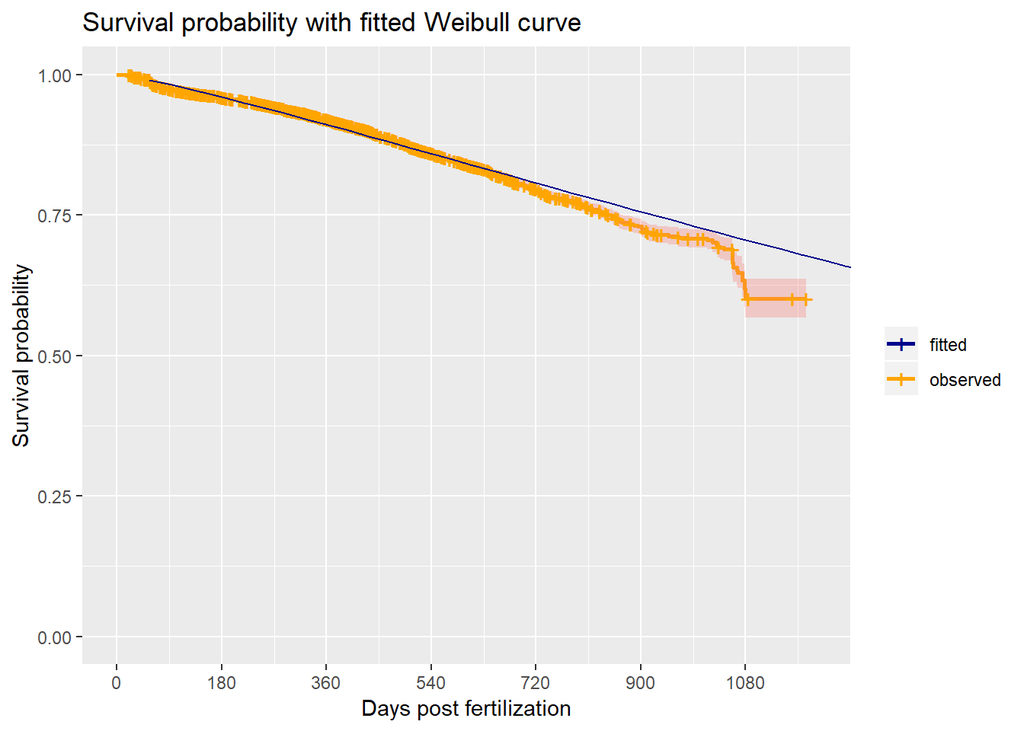

```r
surv_object = Surv(time = df$death_day, event = df$died)
fit = survfit(surv_object ~ 1, data=df)
plt <- ggsurvplot(fit, data = df, break.time.by = 180, xlab = 'Days post fertilization',
                  title = 'Survival probability with fitted Weibull curve',
                  legend.labs = c("observed"),
                  legend.title = NULL)

# Fit the Weibull distribution
# This is a curve of survival probability if death is a random event
wb <- survreg(surv_object ~ 1, data = df) #get the weibull distribution for our data
s <- seq(.01, .99, by = .01)
t <- predict(wb, type = "quantile", p = s, newdata = df[1, ]) #predict a bunch of points from it
out_wb <- data.frame(time = t, surv = 1 - s, upper = NA, lower = NA, std.err = NA) # make a dataframe

plt$plot + geom_line(data = out_wb, aes(x = time, y = surv, color='fitted')) +
  scale_color_manual(name = NULL, values = c("observed"="orange", "fitted" = "darkblue")) +
  guides(fill = FALSE) +
  theme_gray()
```

### Proportional hazard function

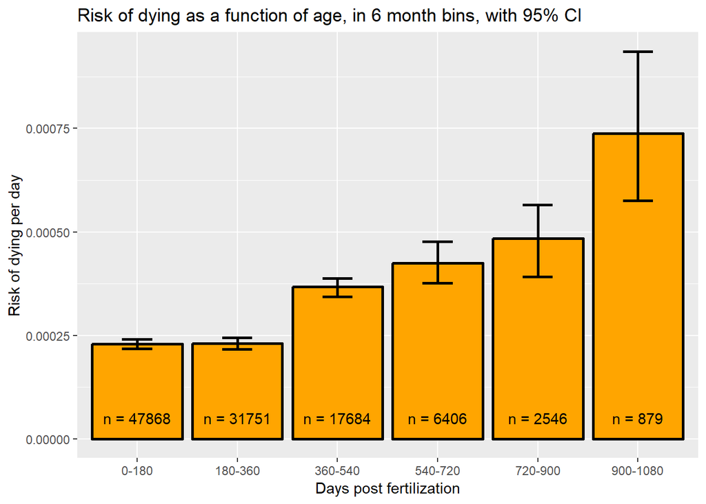

```r
bin_size = 180
invisible(capture.output(haz_fit <- pehaz(df$death_day, as.integer(df$died), width=bin_size)))
day_bins = paste(head(haz_fit$Cuts,-1), tail(haz_fit$Cuts,-1), sep="-")
day_bins = factor(day_bins, levels = day_bins, ordered=T)
hdf = data.frame(days = day_bins, risk = haz_fit$Hazard)
## Re-sample the data many times to create confidence intervals

hazard_bootstrap = function(data, indices){
  d = data[indices,]
  invisible(capture.output(haz_fit <- pehaz(d$death_day, as.integer(d$died), width=bin_size)))
  haz_fit$Hazard
}
bootobject = boot(data = df, statistic = hazard_bootstrap, R=100)
bootstrap.mean = colMeans(bootobject$t)
bootstrap.bias = bootstrap.mean - bootobject$t0
bootstrap.sd = apply(bootobject$t, 2, sd)
bootstrap.u95 = bootstrap.mean + 1.96*bootstrap.sd
bootstrap.l95 = bootstrap.mean - 1.96*bootstrap.sd

hdf$labels = paste("n =",haz_fit$At.Risk)
## drop the last bin; it has very few fish in it
hdf = head(hdf,-1)
bootstrap.u95 = head(bootstrap.u95, -1)
bootstrap.l95 = head(bootstrap.l95, -1)

ggplot(data=hdf, aes(x=days, y=risk, label = labels)) +
  geom_col(fill='orange', colour = "black", size=1) +
  ylab('Risk of dying per day') + xlab('Days post fertilization') +
  ggtitle('Risk of dying as a function of age, in 6 month bins, with 95% CI') +
  geom_errorbar(aes(ymin=bootstrap.l95, ymax=bootstrap.u95), size=1, width=0.3) +
  geom_text(y=0.00005)
```